# Midterm Report

seyma cakir

12/5/2021

set directory and set seed to prevent randomness each calculation.

```r
# set directory and set seed to prevent randomness each calculation.
setwd('D:\\Users\\seyma\\Documents\\GitHub\\fall21-seymacakir\\midterm')
set.seed(448)
```

The data readed from directory as data table.

```r
# read data
main_path <- getwd()

data_path=sprintf('%s/imbalance_series.csv',main_path)
data <-as.data.table( fread(data_path))

# assign id for each observation
data[,id:= 1:.N]
```

The net imbalance as calculated by sum of negative and positive imbalance. It is assigned to classes for net imbalance, there is no equality so the classes is determined as 1 for positive imbalance and -1 for negative imbalance

```r
# check if there is equality

data[net_imb==0]
```

```
## Empty data.table (0 rows and 6 cols): date,hour,positive_imb,negative_imb,net_imb,id
```

```r
#assign classes

data[net_imb>0, class:= 1 ]
data[net_imb<0]$class = -1

data$class = as.factor(data$class)

data[,diff := net_imb -shift(net_imb,1)]
```

## Baseline 1

This baseline method is use as the predictor of hours based on most common classes for the hours.

the frequncy of classes is calculated from train data and assign the prediction of test data.

```r
# create a prediction tabşe
prediction_hours = data.table(hour = 0:23, class =0)

# split data as test and train
train = data[date < '2021-09-25']
train[, baseline_1:= 0]


test = tail(data,7*24)
test[,baseline_1 := 0]

# assign the most common classe as prediction for particular hour.

predictions <-  as.data.table(train %>% group_by(hour) %>%
  summarise(class_1 = sum(class==1),
            class_2  = sum(class== -1) ))

predictions[  class_1 > class_2 , predicted := 1]
predictions[  class_1 < class_2]$predicted = -1

for ( i in (0:23)){
  train[hour == i]$baseline_1 = predictions[hour == i]$predicted
  test[hour == i]$baseline_1 = predictions[hour == i]$predicted

}
# create confusion matrix for calculate accuracy
print("train data")
```

```
## [1] "train data"
```

```r
confusionMatrix(data= as.factor(train$baseline_1), reference = as.factor(train$class))
```

```
## Confusion Matrix and Statistics
##
##           Reference
## Prediction  -1   1
##         -1 455 260
##         1  262 343
##
##                Accuracy : 0.6045
##                  95% CI : (0.5776, 0.631)
##     No Information Rate : 0.5432
##     P-Value [Acc > NIR] : 3.938e-06
##
##                   Kappa : 0.2034
##
##  Mcnemar's Test P-Value : 0.9651
##
##             Sensitivity : 0.6346
##             Specificity : 0.5688
##          Pos Pred Value : 0.6364
##          Neg Pred Value : 0.5669
##              Prevalence : 0.5432
##          Detection Rate : 0.3447
##    Detection Prevalence : 0.5417
##       Balanced Accuracy : 0.6017
##
##        'Positive' Class : -1
##
```

```r
print("test data")
```

```
## [1] "test data"
```

```r
confusionMatrix(data= as.factor(test$baseline_1), reference = as.factor(test$class))
```

```
## Confusion Matrix and Statistics
##
##           Reference
## Prediction -1  1
##         -1 50 41
##         1  35 42
##
##                Accuracy : 0.5476
##                  95% CI : (0.4691, 0.6244)
##     No Information Rate : 0.506
##     P-Value [Acc > NIR] : 0.1579
##
##                   Kappa : 0.0943
##
##  Mcnemar's Test P-Value : 0.5663
##
##             Sensitivity : 0.5882
##             Specificity : 0.5060
##          Pos Pred Value : 0.5495
##          Neg Pred Value : 0.5455
##              Prevalence : 0.5060
##          Detection Rate : 0.2976
##    Detection Prevalence : 0.5417
##       Balanced Accuracy : 0.5471
##
##        'Positive' Class : -1
##
```

The success of baseline 1 method is calculated by accuracy of predictions.

```r
# create a column for predicitons of baseline 1

data[,baseline_1 := c(train$baseline_1, test$baseline_1)]
```

## Baseline 2

In this part the most frequent of class of the most recent five observations is used for predictor of hour three hours from now.

the data recorded for eaxh observation by record the recent observation in columns of data.

```r
# add the class of previous hours but extract last three hours since it will be unkown at prediction time.

for( i in c(4:8) ){
  data[, sprintf("hour_%s",i) := shift(class,i)]
}

# divide data as test and train
train = data[date < '2021-09-25']
train[, baseline_2:= 0]


test = tail(data,7*24)
test[,baseline_2 := 0]

# based on the most frequent imbalance type for the last five hours obseved the predictions assigned.

for ( i in 1:1320) {
  count_class1 = sum(train[i, c(10:14)] == 1,na.rm = TRUE)
  count_class2 = sum(train[i, c(10:14)] == -1, na.rm = TRUE)
  if(count_class1 > count_class2){
    train[i]$baseline_2 = 1
  }
  else {
    train[i]$baseline_2 = -1
  }

}

for ( i in 1:nrow(test)) {
  count_class1 = sum(test[i, c(10:14)] == 1,na.rm = TRUE)
  count_class2 = sum(test[i, c(10:14)] == -1, na.rm = TRUE)
  if(count_class1 > count_class2){
    test[i]$baseline_2 = 1
  }
  else {
    test[i]$baseline_2 = -1
  }

}

# create confusion matrix for calculate accuracy

print("train data")
```

```
## [1] "train data"
```

```r
confusionMatrix(data= as.factor(train$baseline_2), reference = as.factor(train$class))
```

```
## Confusion Matrix and Statistics
##
##           Reference
## Prediction  -1   1
##         -1 511 208
##         1  206 395
##
##                Accuracy : 0.6864
##                  95% CI : (0.6606, 0.7113)
##     No Information Rate : 0.5432
##     P-Value [Acc > NIR] : <2e-16
##
##                   Kappa : 0.3678
##
##  Mcnemar's Test P-Value : 0.9608
##
##             Sensitivity : 0.7127
##             Specificity : 0.6551
##          Pos Pred Value : 0.7107
##          Neg Pred Value : 0.6572
##              Prevalence : 0.5432
##          Detection Rate : 0.3871
##    Detection Prevalence : 0.5447
##       Balanced Accuracy : 0.6839
##
##        'Positive' Class : -1
##
```

```r
print("test data")
```

```
## [1] "test data"
```

```r
confusionMatrix(data= as.factor(test$baseline_2), reference = as.factor(test$class))
```

```
## Confusion Matrix and Statistics
##
##           Reference
## Prediction -1  1
##         -1 40 41
##         1  45 42
##
##                Accuracy : 0.4881
##                  95% CI : (0.4103, 0.5663)
##     No Information Rate : 0.506
##     P-Value [Acc > NIR] : 0.7054
##
##                   Kappa : -0.0234
##
##  Mcnemar's Test P-Value : 0.7463
##
##             Sensitivity : 0.4706
##             Specificity : 0.5060
##          Pos Pred Value : 0.4938
##          Neg Pred Value : 0.4828
##              Prevalence : 0.5060
##          Detection Rate : 0.2381
##    Detection Prevalence : 0.4821
##       Balanced Accuracy : 0.4883
##
##        'Positive' Class : -1
##
```

## Summary

In this task alternative approaches used to classify and predict data to compare baseline methods.

The approaches used are:

The most recent 24,12, and 9 hours before prediction time by exculiding last 3 hours processed as time-series f-of each observation.

By using raw data and differntiated data time-series knn k=1 classifier based on Euclidean distance knn k=5 classifier based on Euclidean distance knn k=10 classifier based on Euclidean distance

By using Raw data time series knn k=1 classifier based on DTW distance + no window knn k=5 classifier based on DTW distance + no window knn k=10 classifier based onDTW distance +no window

The window paramater is not used since the data have small interval.

By using raw data time-series knn k=1 based on LCSS + epsilon=0.05 + no window knn k=5 based on LCSS + epsilon=0.05 + no window knn k=10 based on LCSS + epsilon=0.05 + no window

The observation of same hours of previous 3 days and 7 days is used as time series as preproccessing By using raw data time-series knn k=1 classifier based on Euclidean distance knn k=5 classifier based on Euclidean distance knn k=10 classifier based on Euclidean distance

In recent hours data divided into hours since the consecutive hours have very similar time series but in the and average accuracy is used.

The data methods are tried by repeated cross validation technique.

In the end the accuracy is calculated for each method.

## Methods

```r
# read data again
main_path <- getwd()

data_path=sprintf('%s/imbalance_series.csv',main_path)
data <-as.data.table( fread(data_path))

# assign id for each observation
data[,id:= 1:.N]

# check if there is equality

data[net_imb==0]
```

```
## Empty data.table (0 rows and 6 cols): date,hour,positive_imb,negative_imb,net_imb,id
```

```r
# no equality two classes is observed
#assign classes

data[net_imb>0, class:= 1 ]
data[net_imb<0]$class = -1

data$class = as.factor(data$class)

data[,diff := net_imb -shift(net_imb,1)]


# get time series by previous hours for each time.

for( i in c(1:24) ){


  data[, sprintf("hour_%s",i) := shift(net_imb,i)]

}

for( i in c(1:24) ){


  data[, sprintf("diff_%s",i) := shift(diff,i)]

}
```

```r
# function of k-nn classifier for k 1,5,10

k_levels=c(1,5,10)

nn_classify_cv=function(dist_matrix,train_class,test_indices,k=1){

    test_distances_to_train=dist_matrix[test_indices,]
    test_distances_to_train=test_distances_to_train[,-test_indices]
    train_class=train_class[-test_indices]
    #print(str(test_distances_to_train))
    ordered_indices=apply(test_distances_to_train,1,order)
    if(k==1){
        nearest_class=as.numeric(trainclass[as.numeric(ordered_indices[1,])])
        nearest_class=data.table(id=test_indices,nearest_class)
    } else {
        nearest_class=apply(ordered_indices[1:k,],2,function(x) {trainclass[x]})
        nearest_class=data.table(id=test_indices,t(nearest_class))
    }

    long_nn_class=melt(nearest_class,'id')

    class_counts=long_nn_class[,.N,list(id,value)]
    class_counts[,predicted_prob:=N/k]
    wide_class_prob_predictions=dcast(class_counts,id~value,value.var='predicted_prob')
    wide_class_prob_predictions[is.na(wide_class_prob_predictions)]=0
    class_predictions=class_counts[,list(predicted=value[which.max(N)]),by=list(id)]


    return(list(prediction=class_predictions,prob_estimates=wide_class_prob_predictions))

}

# the cross validation paramters set.
nof_rep=3
n_fold=5
```

time-series approach from last 24 hours to last 3 hours

```r
for(i in 0:23){

# data divided by hours and the time-series are selected.
traindata <- data[hour == i ,12:32][2:55]

trainclass <- data[hour == i ,"class"][2:55]$class
diff_train <- data[hour == i ,37:56][2:55]
testdata <- data[hour == i ,12:32][56:62]
testclass <- data[hour == i ,"class"][56:62]$class


cv_indices=generateCVRuns(trainclass, ntimes =nof_rep, nfold = n_fold,
                          leaveOneOut = FALSE, stratified = TRUE)

# calculate distances and store them to save time

large_number=1000000000
dist_euc=as.matrix(dist(traindata))
diag(dist_euc)=large_number
fwrite(dist_euc,sprintf('%s/distances/24/euc_raw_dist-%s.csv',main_path,i),col.names=F)

dist_diff_euc=as.matrix(dist(diff_train))
diag(dist_diff_euc)=large_number
fwrite(dist_diff_euc,sprintf('%s/distances/24/euc_diff_dist-%s.csv',main_path,i),col.names=F)

dist_dtw=as.matrix(dtwDist(traindata))
diag(dist_dtw)=large_number
fwrite(dist_dtw,sprintf('%s/distances/24/dtw_raw_dist-%s.csv',main_path,i),col.names=F)

dist_lcss=TSDatabaseDistances(traindata,distance='lcss', epsilon = 0.05)
dist_lcss=as.matrix(dist_lcss)
diag(dist_lcss)=large_number
fwrite(dist_lcss,sprintf('%s/distances/24/lcss_raw-%s.csv',main_path,i),col.names=F)

dist_folder=sprintf('%s/distances/24/',main_path)
dist_files=list.files(dist_folder, full.names=T)
}

# the accuracy values are calculated vy cross validation

result=vector('list',length(dist_files)*nof_rep*n_fold*length(k_levels))
iter=1
for(m in 1:length(dist_files)){
    #print(dist_files[m])
    dist_mat=as.matrix(fread(dist_files[m],header=FALSE))
    for(i in 1:nof_rep){
        this_fold=cv_indices[[i]]
        for(j in 1:n_fold){
            test_indices=this_fold[[j]]
            for(k in 1:length(k_levels)){
                current_k=k_levels[k]
                current_fold=nn_classify_cv(dist_mat,trainclass,test_indices,k=current_k)
                accuracy=sum(trainclass[test_indices]==current_fold$prediction$predicted)/length(test_indices)
                approach= str_split(str_split(dist_files[m],"/")[[1]][10], "-")[[1]][1]
                tmp=data.table(time_interval= 24, approach = approach, hour=str_split(dist_files[m],"-")[[1]][3],repid=i,foldid=j,
                               k=current_k,acc=accuracy)
                result[[iter]]=tmp
                iter=iter+1

            }

        }

    }

}

# results recorded as list

list_of_24=rbindlist(result)
```

time-series approach from last 12 hours to last 3 hours

```r
for(i in 0:23){

# data divided by hours and the time-series are selected.
traindata <- data[hour == i ,12:20][2:55]
trainclass <- data[hour == i ,"class"][2:55]$class
traindata <- data[hour == i ,12:20][2:55]
diff_train <- data[hour == i ,37:44][2:55]
testclass <- data[hour == i ,"class"][56:62]$class


cv_indices=generateCVRuns(trainclass, ntimes =nof_rep, nfold = n_fold,
                          leaveOneOut = FALSE, stratified = TRUE)

# calculate distances store them to save time

large_number=1000000000
dist_euc=as.matrix(dist(traindata))
diag(dist_euc)=large_number
fwrite(dist_euc,sprintf('%s/distances/12/euc_raw_dist-%s.csv',main_path,i),col.names=F)

dist_diff_euc=as.matrix(dist(diff_train))
diag(dist_diff_euc)=large_number
fwrite(dist_diff_euc,sprintf('%s/distances/12/euc_diff_dist-%s.csv',main_path,i),col.names=F)

dist_dtw=as.matrix(dtwDist(traindata))
diag(dist_dtw)=large_number
fwrite(dist_dtw,sprintf('%s/distances/12/dtw_raw_dist-%s.csv',main_path,i),col.names=F)

dist_lcss=TSDatabaseDistances(traindata,distance='lcss', epsilon = 0.05)
dist_lcss=as.matrix(dist_lcss)
diag(dist_lcss)=large_number
fwrite(dist_lcss,sprintf('%s/distances/12/lcss_raw-%s.csv',main_path,i),col.names=F)

dist_folder=sprintf('%s/distances/12/',main_path)
dist_files=list.files(dist_folder, full.names=T)
}

# the accuracy values are calculated

result=vector('list',length(dist_files)*nof_rep*n_fold*length(k_levels))
iter=1
for(m in 1:length(dist_files)){
    #print(dist_files[m])
    dist_mat=as.matrix(fread(dist_files[m],header=FALSE))
    for(i in 1:nof_rep){
        this_fold=cv_indices[[i]]
        for(j in 1:n_fold){
            test_indices=this_fold[[j]]
            for(k in 1:length(k_levels)){
                current_k=k_levels[k]
                current_fold=nn_classify_cv(dist_mat,trainclass,test_indices,k=current_k)
                accuracy=sum(trainclass[test_indices]==current_fold$prediction$predicted)/length(test_indices)
                approach= str_split(str_split(dist_files[m],"/")[[1]][10], "-")[[1]][1]
                tmp=data.table(time_interval = 12, approach = approach, hour=str_split(dist_files[m],"-")[[1]][3],repid=i,foldid=j,
                               k=current_k,acc=accuracy)
                result[[iter]]=tmp
                iter=iter+1

            }

        }

    }

}
# the results are recorded as list
list_of_12=rbindlist(result)
```

time-series approach from last 9 hours to last 3 hours

```r
for(i in 0:23){
traindata <- data[hour == i ,12:17][2:55]
diff_train <- data[hour == i ,37:41][2:55]
trainclass <- data[hour == i ,"class"][2:55]$class
testdata <- data[hour == i ,12:17][56:62]
testclass <- data[hour == i ,"class"][56:62]$class


cv_indices=generateCVRuns(trainclass, ntimes =nof_rep, nfold = n_fold,
                          leaveOneOut = FALSE, stratified = TRUE)

# calculate distances and store them to save time

large_number=1000000000
dist_euc=as.matrix(dist(traindata))
diag(dist_euc)=large_number
fwrite(dist_euc,sprintf('%s/distances/9/euc_raw_dist-%s.csv',main_path,i),col.names=F)

dist_diff_euc=as.matrix(dist(diff_train))
diag(dist_diff_euc)=large_number
fwrite(dist_diff_euc,sprintf('%s/distances/9/euc_diff_dist-%s.csv',main_path,i),col.names=F)

dist_dtw=as.matrix(dtwDist(traindata))
diag(dist_dtw)=large_number
fwrite(dist_dtw,sprintf('%s/distances/9/dtw_raw_dist-%s.csv',main_path,i),col.names=F)

dist_lcss=TSDatabaseDistances(traindata,distance='lcss', epsilon = 0.05)
dist_lcss=as.matrix(dist_lcss)
diag(dist_lcss)=large_number
fwrite(dist_lcss,sprintf('%s/distances/9/lcss_raw-%s.csv',main_path,i),col.names=F)

dist_folder=sprintf('%s/distances/9/',main_path)
dist_files=list.files(dist_folder, full.names=T)
}

# accuracy values are calculated

result=vector('list',length(dist_files)*nof_rep*n_fold*length(k_levels))
iter=1
for(m in 1:length(dist_files)){
    #print(dist_files[m])
    dist_mat=as.matrix(fread(dist_files[m],header=FALSE))
    for(i in 1:nof_rep){
        this_fold=cv_indices[[i]]
        for(j in 1:n_fold){
            test_indices=this_fold[[j]]
            for(k in 1:length(k_levels)){
                current_k=k_levels[k]
                current_fold=nn_classify_cv(dist_mat,trainclass,test_indices,k=current_k)
                accuracy=sum(trainclass[test_indices]==current_fold$prediction$predicted)/length(test_indices)
                approach= str_split(str_split(dist_files[m],"/")[[1]][10], "-")[[1]][1]
                tmp=data.table(time_interval = 9, approach = approach, hour=str_split(dist_files[m],"-")[[1]][3],repid=i,foldid=j,
                               k=current_k,acc=accuracy)
                result[[iter]]=tmp
                iter=iter+1

            }

        }

    }

}

# results are recorded as list

list_of_9=rbindlist(result)
```

The accuracy values for each method is listed to compare results

```r
# results merged and grouped to calculate avarage accuracy

overall_results = rbind(list_of_24,list_of_12,list_of_9)
overall_results[,list(avg_acc=mean(acc),sdev_acc=sd(acc),result_count=.N),by=list(approach,k,time_interval)]
```

```
##          approach  k time_interval   avg_acc   sdev_acc result_count
##  1:  dtw_raw_dist  1            24 0.1835354 0.10787833          360
##  2:  dtw_raw_dist  5            24 0.6566667 0.15281787          360
##  3:  dtw_raw_dist 10            24 0.6825000 0.13361282          360
##  4: euc_diff_dist  1            24 0.2177778 0.12809963          360
##  5: euc_diff_dist  5            24 0.6243687 0.13700471          360
##  6: euc_diff_dist 10            24 0.6488889 0.11842663          360
##  7:  euc_raw_dist  1            24 0.1780808 0.12485048          360
##  8:  euc_raw_dist  5            24 0.6551768 0.15670535          360
##  9:  euc_raw_dist 10            24 0.6967929 0.13313057          360
## 10:      lcss_raw  1            24 0.6109091 0.03567853          360
## 11:      lcss_raw  5            24 0.3890909 0.03567853          360
## 12:      lcss_raw 10            24 0.3890909 0.03567853          360
## 13:  dtw_raw_dist  1            12 0.2105808 0.11682838          360
## 14:  dtw_raw_dist  5            12 0.6391919 0.12528120          360
```

[output cut: 23 more lines]

In this part of report,the same hour of earlier days is used as prediction data.

For use the three days earlier observation to predict last day at same hour

```r
# read data again
main_path <- getwd()

data_path=sprintf('%s/imbalance_series.csv',main_path)
data <-as.data.table( fread(data_path))

# assign id for each observation
data[,id:= 1:.N]

# check if there is equality

data[net_imb==0]
```

```
## Empty data.table (0 rows and 6 cols): date,hour,positive_imb,negative_imb,net_imb,id
```

```r
# no equality two classes is observed
#assign classes

data[net_imb>0, class:= 1 ]
data[net_imb<0]$class = -1

data$class = as.factor(data$class)

data[,diff := net_imb -shift(net_imb,1)]


# get time series by previous hours for each time.

for( i in c(1:7) ){


  data[, sprintf("day_%s",i) := shift(net_imb,i*24)]

}
```

```r
# the paramter is set.
nof_rep=3
n_fold=5
k_levels=c(1,5,10)

# data split as test and train.
traindata <- data[73:(1488-7*24), 9:11]
trainclass <- data[73:(1488-7*24)]$class

cv_indices=generateCVRuns(trainclass, ntimes =nof_rep, nfold = n_fold,
                          leaveOneOut = FALSE, stratified = TRUE)

# calculate distances and store them to save time

large_number=1000000000
dist_euc=as.matrix(dist(traindata))
diag(dist_euc)=large_number
fwrite(dist_euc,sprintf('%s/distances/3/euc_raw_dist.csv',main_path),col.names=F)

# This calculations is needed too much effort so it is not calculated.
#dist_dtw=as.matrix(dtwDist(traindata))
#diag(dist_dtw)=large_number
#fwrite(dist_dtw,sprintf('%s/distances/3/dtw_raw_dist.csv',main_path),col.names=F)

#dist_lcss=TSDatabaseDistances(traindata,distance='lcss', epsilon = 0.05)
#dist_lcss=as.matrix(dist_lcss)
#diag(dist_lcss)=large_number
#fwrite(dist_lcss,sprintf('%s/distances/3/lcss_raw.csv',main_path,i),col.names=F)

dist_folder=sprintf('%s/distances/3/',main_path)
dist_files=list.files(dist_folder, full.names=T)


# the accuracy values calculated

result=vector('list',length(dist_files)*nof_rep*n_fold*length(k_levels))
iter=1
for(m in 1:length(dist_files)){
    #print(dist_files[m])
    dist_mat=as.matrix(fread(dist_files[m],header=FALSE))
    for(i in 1:nof_rep){
        this_fold=cv_indices[[i]]
        for(j in 1:n_fold){
            test_indices=this_fold[[j]]
            for(k in 1:length(k_levels)){
                current_k=k_levels[k]
                current_fold=nn_classify_cv(dist_mat,trainclass,test_indices,k=current_k)
                accuracy=sum(trainclass[test_indices]==current_fold$prediction$predicted)/length(test_indices)

                tmp=data.table(time_interval= "3 days", approach = "dist_euc_raw",repid=i,foldid=j,
                               k=current_k,acc=accuracy)
                result[[iter]]=tmp
                iter=iter+1

            }

        }

    }

}
list_of_3days=rbindlist(result)
```

The observation of the same hour from 7 days earlier to the prediction date is used as time-series.

```r
# create train and test data
traindata <- data[(7*24 +1):(1488-7*24), 9:15]
trainclass <- data[(7*24 +1 ):(1488-7*24)]$class
cv_indices=generateCVRuns(trainclass, ntimes =nof_rep, nfold = n_fold,
                          leaveOneOut = FALSE, stratified = TRUE)

# calculate distances and store them to save time

large_number=1000000000
dist_euc=as.matrix(dist(traindata))
diag(dist_euc)=large_number
fwrite(dist_euc,sprintf('%s/distances/7/euc_raw_dist.csv',main_path),col.names=F)

#dist_dtw=as.matrix(dtwDist(traindata))
#diag(dist_dtw)=large_number
#fwrite(dist_dtw,sprintf('%s/distances/7/dtw_raw_dist.csv',main_path),col.names=F)

#dist_lcss=TSDatabaseDistances(traindata,distance='lcss', epsilon = 0.05)
#dist_lcss=as.matrix(dist_lcss)
#diag(dist_lcss)=large_number
#fwrite(dist_lcss,sprintf('%s/distances/7/lcss_raw.csv',main_path,i),col.names=F)

dist_folder=sprintf('%s/distances/7/',main_path)
dist_files=list.files(dist_folder, full.names=T)


# the accuracy values calculated

result=vector('list',length(dist_files)*nof_rep*n_fold*length(k_levels))
iter=1
for(m in 1:length(dist_files)){
    #print(dist_files[m])
    dist_mat=as.matrix(fread(dist_files[m],header=FALSE))
    for(i in 1:nof_rep){
        this_fold=cv_indices[[i]]
        for(j in 1:n_fold){
            test_indices=this_fold[[j]]
            for(k in 1:length(k_levels)){
                current_k=k_levels[k]
                current_fold=nn_classify_cv(dist_mat,trainclass,test_indices,k=current_k)
                accuracy=sum(trainclass[test_indices]==current_fold$prediction$predicted)/length(test_indices)

                tmp=data.table(time_interval= "7 days", approach = "dist_euc_raw",repid=i,foldid=j,
                               k=current_k,acc=accuracy)
                result[[iter]]=tmp
                iter=iter+1

            }

        }

    }

}

list_of_7days=rbindlist(result)
```

## Discussion

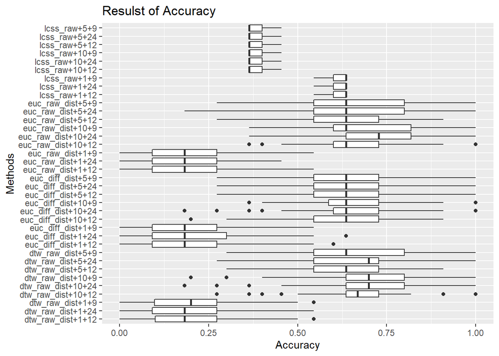

```r
overall_results = rbind(list_of_3days,list_of_7days)
x <- overall_results[,list(avg_acc=mean(acc),sdev_acc=sd(acc),result_count=.N),by=list(approach,k,time_interval)]
overall_results = rbind(list_of_24,list_of_12,list_of_9)
y<- overall_results[,list(avg_acc=mean(acc),sdev_acc=sd(acc),result_count=.N),by=list(approach,k,time_interval)]


ggplot(overall_results,aes(x=paste0(approach,'+',k, '+', time_interval ), y=acc)) +
geom_boxplot() + labs(
  title = "Resulst of Accuracy",
  x = "Methods",
  y = "Accuracy"
) +
coord_flip()
```

```r
results <- rbind(x,y)
results[avg_acc == max(results$avg_acc)]
```

```
##        approach  k time_interval   avg_acc  sdev_acc result_count
## 1: euc_raw_dist 10            24 0.6967929 0.1331306          360
```

```r
# read data again
main_path <- getwd()

data_path=sprintf('%s/imbalance_series.csv',main_path)
data <-as.data.table( fread(data_path))

# assign id for each observation
data[,id:= 1:.N]

# check if there is equality

data[net_imb==0]
```

```
## Empty data.table (0 rows and 6 cols): date,hour,positive_imb,negative_imb,net_imb,id
```

```r
# no equality two classes is observed
#assign classes

data[net_imb>0, class:= 1 ]
data[net_imb<0]$class = -1

data$class = as.factor(data$class)

data[,diff := net_imb -shift(net_imb,1)]


# get time series by previous hours for each time.

for( i in c(1:24) ){


  data[, sprintf("hour_%s",i) := shift(net_imb,i)]

}

# predictions

for(i in 0:23){

testdata <- data[hour == i ,12:17][56:62]
testclass <- data[hour == i ,"class"][56:62]$class


#cv_indices=generateCVRuns(trainclass, ntimes =nof_rep, nfold = n_fold,
#                          leaveOneOut = FALSE, stratified = TRUE)

# calculate distances and store them to save time

large_number=1000000000
dist_euc=as.matrix(dist(traindata))
diag(dist_euc)=large_number
fwrite(dist_euc,sprintf('%s/distances/test/euc_raw_dist-%s.csv',main_path,i),col.names=F)

dist_folder=sprintf('%s/distances/test/',main_path)
dist_files=list.files(dist_folder, full.names=T)
}

# accuracy values are calculated
```

I could not manage the calculate predictions.

However, the accuarcy should be calculated based on predictions and compared with baseline methods.